# Washington Crime (WAC)

Alyssa Limit, Nathan Narayana, Thomas Emnetu

11/13/2022

Be Safe with WAC by knowing the safety status in Washington Area!

## Abstract

As we looked into the crime rate in the USA, we wondered why it’s absurdly high. Then we ask ourselves, “If people can open their weather app to understand the weather status in an area, why isn’t there a crime app informing the safety status of an area we’re in?”. Thus, our crew creates WAC (Washington Crime), an integrated platform that tells us the area safety status in based on safety score, prison rate, and common type of crime in an area to address the problem.

## Keywords

| Positive | Negative |
| --- | --- |
| Community | Violence |
| Safety | Criminal-Activity |

[output not shown]

## Introduction

During the first few weeks of the quarter, the UW community has been swamped with violence. There has been no sort of general system or data that tackles the issue of reducing victims caused by common crimes. This is important as our basic rights and needs as humans have the right to their safety. As informatics students, we try to accomplish this through our way of using knowledge learned in the class. Our goal is to reduce the number of victims from these criminal acts starting within the state of Washington. We plan to do this by collecting a set of data from the official government website of reported crimes around each county in Washington. These crimes include theft, shootings, vandalism, assault, and many more. We then proceed to analyze and present the data to the public of the safety score of area they are in, prison rate, and common type of crime so they can make informed decision in avoiding certain areas with low safety score. The summary of the data will be presented on a website.

## Problem Domain

#### Project Framing

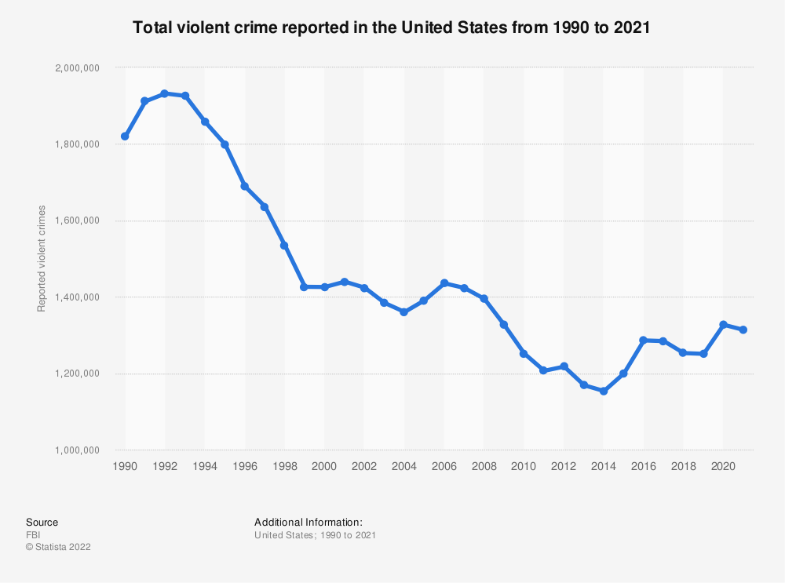

This data is obtained through [Statista](https://www.statista.com) by FBI, 2022

#### Human Values

Our team believes that every Washingtonians deserve to feel safe living here. Thus, we create WAC which can help Washingtonians make informed decisions on when to go out and understand if the area they’re in is safe or not. We realized that crimes data are all scattered on the internet. We think it’d be great if we can compile all the safety status based on safety score, prison rate, and common type of crime in an area that people can see it in a platform.

#### Stakeholders (Direct & Indirect)

Direct Stakeholders will be the users. The users would most likely be Washington residents or visitors since we only provide this platform for Washington area based on the counties. It directly impacts their decision making by being more careful of visiting certain areas. Thus, they can change their decisions of visiting the area according to the safety status. As for the indirect stakeholders, it can be the business owners the unsafe place. Their customer waves may change depending on the safety status. Business owners in the area with high safety score, low prison rate can receive more customers.

#### Possible Harms and Benefits

The Washingtonian may benefit from this platform because they are being informed of unsafe place. It helps them make an informed decision to go out or not so they can make preventive measures. However, some criminals may take advantage of this app. They will be able to see the safety status and start committing crimes in the middle of safe area. Furthermore, this app only provides existing information but would not predict future crimes since we do not have our own investigation team & don’t provide safety status real-time update.

## Research Questions

1. **Are UW students more susceptible to violent crimes than Washington State residents?**
   - This question is important to understand the sentiment surrounding the basis of our project. What motivates this question is the fact that if students feel safe and have no concerns about the violent criminal activity, our project ceases to have any relevancy or impact.
2. **What would make the UW community feel more safe as criminal activity continues to rise?**
   - This question is important because the suggestions that the UW community poses are a direct reflection of things that would increase their feeling of safety. What motivates this question is rather than guess and check what would make the community feel safer, we can ask the community and expand off of their insights.
3. **What are some ways that the UW community can keep each other informed on the severity of the criminal activity in the area?**
   - This question is important because it allows us to analyze what the community at hand believes will be beneficial to keep them informed for their safety. What motivates this question is CBPR (community based participatory research) which is the research approach that equitably involves community members in the research process to effectively target the problem at hand.
4. **In what ways does our data hold power?**
   - This questions is important because we will actively be in communication with marginalized groups and stakeholders. Being cognisent of the power we hold, working with this data, is essential so that we can better cater towards those who will be affected by the data. Not solely the ones who consume it.

## The Dataset

| Name | Observations | Variables |
| --- | --- | --- |
| [Criminal Justice Data Book](https://sac.ofm.wa.gov/data) | 1272 | 228 |

3. Here is the APA citation for the data:

*Safest cities in Washington, 2021.* Background Checks.org. Retrieved November 14, 2022, from https://backgroundchecks.org/safest-cities-in-washington.html

The URL can be found through this link https://backgroundchecks.org/safest-cities-in-washington.html

*National Incident-Based Reporting System (NIBRS).* Incident Based Reporting System. Retrieved November 14, 2022, from https://sac.ofm.wa.gov/sites/default/files/public/cjdb/nibrs.html

The URL can be found through this link https://sac.ofm.wa.gov/sites/default/files/public/cjdb/nibrs.html

4. The data is collected by Washington Statistical Analysis Center. Washington Statistical Analysis Center or WSAC specializes in collecting data surrounding crime and justice. Their data is used for Washington policy and budget development. Bureau of Justice Statistics, Office of Justice Programs, and US Department of Justice funded WSAC through a grant. Since the data from Washington Statistical Analysis Center is being used for creating and revising Washington Policy, those who gained benefit from it can be any institutions that may be related to crime prevention. Furthermore, this data is being used as the reference for budget development, some institutions may receive more or less budget because of this data. Hence, reliable data surveillance must be very strict. The commissioner need to make sure that the data is not being manipulated so people can take advantage from it. Washington Statistical Analysis Center uses Summary Reporting System (SRS) and National Incident Based Reporting System (NIBRS) and they are part of FBI’s Uniform Crime Reporting System. We obtained the data from Washington Statistical Analysis Center’s website then we downloaded the xlsx format, and we definitely credit the data source.

## Expected Limitations

- Our findings can have major implications on the quality of livelihood and safety of citizens of Washington. For policymakers, implications would suggest investing more resources into policing counties that have higher rater of criminal activity. Or perhaps a certain area always has high crime at a certain hour, policymakers could look into requiring a lockdown past 1am where if you don’t have lawful reason to be outside you’d receive a citation.
- We collectively expect the our project to concretely display which areas to avoid in Washington and what times to avoid them. An implication that arises for technologists is expanding off of our findings to include the entire Pacific Northwest or conversely, every city in Washington.
- Another implication surrounding the Designers that encounter our work would be operability. For example, a designer could find our work fascinating, but the ease-of-use isn’t fairly easy. A UX Designer would be able to analyze the users needs and understand the most effective way to orient and organize information to make the product viable and inclusive to everyone.

## Limitations

- Although our dataset may have the times and locations of when each crime is commonly committed, we cannot guarantee the exact percentage of risk a certain time or location has.
- Our analysis of data does not yet have the exact accuracy of predicting when a crime will happen as our data is based on data that has been collected in the past. It requires a certain type of complicated algorithm(s) to be able to predict when a crime will happen.
- There is insufficient data from the years of 2021-2022. In order to fully analyze the crimes that happened in Washington State, it requires us to also analyze the reported crimes that happened recently. This allows space for errors and inaccuracy.

## Acknowledgements

We want to express our gratitude to INFO 201 Instructors: Thomas Winegarden and Yubing Tian for guiding us through this Group Project and giving us great feedback.

## References

FBI. (October 5, 2022). *Total violent crime reported in the United States from 1990 to 2021 [Graph].* Statista. Retrieved November 01, 2022, from https://www.statista.com/statistics/191129/reported-violent-crime-in-the-us-since-1990/

Lopez, G. (2022, September 23). *A shift in crime.* The New York Times. Retrieved October 31, 2022, from https://www.nytimes.com/2022/09/23/briefing/crime-rates-murder-robberies-us.html

Magaña, D. Z., & Zhou, A. (2022, October 3). *4 injured in University District shooting were UW students.* The Seattle Times. Retrieved October 31, 2022, from https://www.seattletimes.com/seattle-news/law-justice/4-injured-in-university-district-shooting-were-uw-students/

*National Incident-Based Reporting System (NIBRS).* Incident Based Reporting System. Retrieved November 14, 2022, from https://sac.ofm.wa.gov/sites/default/files/public/cjdb/nibrs.html

*Safest cities in Washington, 2021.* Background Checks.org. Retrieved November 14, 2022, from https://backgroundchecks.org/safest-cities-in-washington.html

## Appendix A: Questions

Is there more features that you love and would be great to be included in our project?

## Chart #1 -Thomas

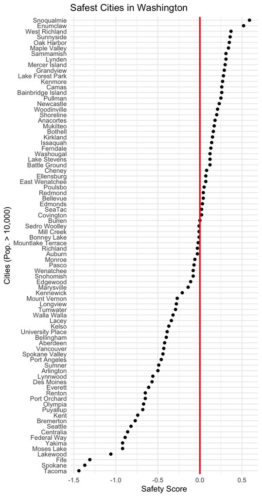

## Table

[output not shown]

[output cut: 52 more lines]

## ACCESSING THE /source DIRECTORY

### Example 1: Source some code and run a function

```r
# Example 1: Note relative path, which can be read: Up one
# directory(..), down into source (/source), and
# then "source" an R file (data_access.R)
source("../source/chart1.R")
data_access_test()
```

[output not shown]

### Example 2: Initialize a variable and then use it

```r
source("../source/chart1.R")
```